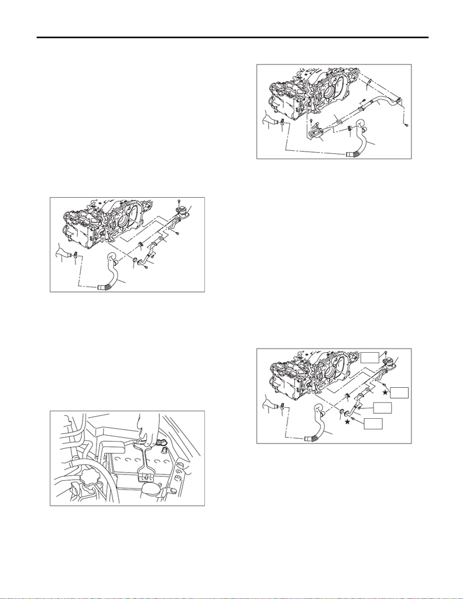

EC(STI)-54

Secondary Air Combination Valve

EMISSION CONTROL (AUX. EMISSION CONTROL DEVICES)

13.Secondary Air Combination

Valve

A: REMOVAL

1. SECONDARY AIR COMBINATION

VALVE LH

1) Disconnect the ground cable from battery.

2) Remove the intercooler. <Ref. to IN(STI)-13,

REMOVAL, Intercooler.>

3) Disconnect the connector from the secondary air

combination valve LH.

4) Disconnect the air duct A.

5) Remove the secondary air pipe LH.

6) Remove the secondary air combination valve

LH.

2. SECONDARY AIR COMBINATION

VALVE RH

1) Disconnect the ground cable from battery.

2) Remove the intercooler. <Ref. to IN(STI)-13,

REMOVAL, Intercooler.>

3) Remove the intake manifold. <Ref. to FU(STI)-

17, REMOVAL, Intake Manifold.>

4) Disconnect the air duct A.

5) Disconnect the secondary air pipe RH.

6) Remove the secondary air combination valve

RH.

B: INSTALLATION

1. SECONDARY AIR COMBINATION

VALVE LH

Install in the reverse order of removal.

NOTE:

Use a new gasket.

Tightening torque:

T1: 9 N·m (0.9 kgf-m, 6.6 ft-lb)

T2: 19 N·m (1.9 kgf-m, 14.0 ft-lb)

(A) Secondary air combination valve LH

(B) Clip

(C) Air duct A

(D) Gasket

(E) Air duct B

(F) Secondary air pipe LH

(G) Gasket

(G)

(B)

(E)

(B)

(C)

(A)

(F)

(D)

EC-02720

IN-00203

(A) Secondary air combination valve RH

(B) Clip

(C) Air duct A

(D) Gasket

(E) Air duct B

(F) Secondary air pipe RH

(G) Gasket

(A) Secondary air combination valve LH

(B) Clip

(C) Air duct A

(D) Gasket

(E) Air duct B

(F) Secondary air pipe LH

(G) Gasket

(B)

(E)

(B)

(C)

(D)

(G)

(F)

(A)

EC-02721

(G)

(B)

(E)

(B)

(C)

(A)

(F)

(D)

EC-02722

T2

T1

T2

T2

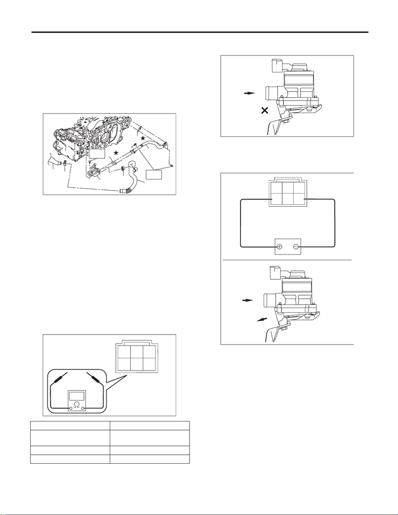

EC(STI)-55

Secondary Air Combination Valve

EMISSION CONTROL (AUX. EMISSION CONTROL DEVICES)

2. SECONDARY AIR COMBINATION

VALVE RH

Install in the reverse order of removal.

NOTE:

Use a new gasket.

Tightening torque:

T1: 9 N·m (0.9 kgf-m, 6.6 ft-lb)

T2: 19 N·m (1.9 kgf-m, 14.0 ft-lb)

C: INSPECTION

1. SECONDARY AIR COMBINATION

VALVE LH

1) Check that the secondary air combination valve

LH has no deformation, cracks or other damages.

2) Check the resistance between the terminals of

secondary air combination valve LH.

3) Check that air does not come out from (B) when

air is blown into (A).

4) Connect the battery positive terminal to the ter-

minal No. 6 and the battery negative terminal to the

terminal No. 4. Check that air is discharged from

(B), when supplying air to (A).

2. SECONDARY AIR COMBINATION

VALVE RH

1) Check that the secondary air combination valve

RH has no deformation, cracks or other damages.

(A) Secondary air combination valve RH

(B) Clip

(C) Air duct A

(D) Gasket

(E) Air duct B

(F) Secondary air pipe RH

(G) Gasket

Terminal No. Standard

4 and 6

5.0±0.5 Ω (when 20°C

(68°F))

2 and 3 15 kΩ or less

1 and 2 4.5 kΩ or less

(B)

(E)

(B)

(C)

(D)

(G)

(F)

(A)

EC-02723

T2

T1

EC-02429

31

654

2

EC-02476

(A)

(B)

31

654

2

EC-02477

(A)

(B)

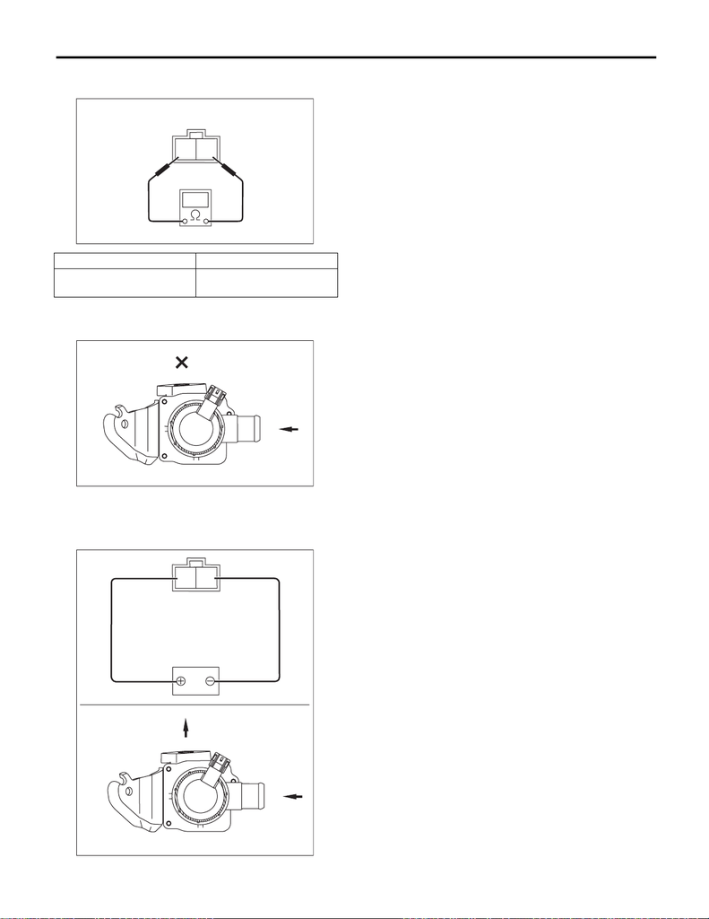

EC(STI)-56

Secondary Air Combination Valve

EMISSION CONTROL (AUX. EMISSION CONTROL DEVICES)

2) Check the resistance between the terminals of

secondary air combination valve RH.

3) Check that air does not come out from (B) when

air is blown into (A).

4) Connect the battery positive terminal to the ter-

minal No. 2 and the battery negative terminal to the

terminal No. 1. Check that air is discharged from

(B), when supplying air to (A).

3. OTHER INSPECTIONS

1) Check that the secondary air pipe has no defor-

mation, cracks or other damages.

2) Check that the air duct has no cracks, damage

or loose part.

Terminal No. Standard

1 and 2

5.0±0.5 Ω (when 20°C

(68°F))

2

1

EC-02428

EC-02478

(A)

(B)

EC-02479

2

1

(A)

(B)

[figure not shown]

INTAKE (INDUCTION)

IN(STI)

Page

1. General Description ...................................................................................2

2. Air Cleaner Element ...................................................................................8

3. Air Cleaner Case ........................................................................................9

4. Air Intake Duct ..........................................................................................11

5. Intake Duct ...............................................................................................12

6. Intercooler ................................................................................................13

7. Turbocharger ............................................................................................16

8. Air By-pass Valve .....................................................................................20

9. Resonator Chamber .................................................................................21

10. Chamber Assembly ..................................................................................22